# Risk Factor Analysis

## Outcome Variable

**Outcome Variable:** haz

## Predictor Variables

**Intervention Variable:** gagebrth

**Adjustment Set:**

unadjusted

## Stratifying Variables

The analysis was stratified on these variable(s):

- agecat
- studyid
- country

## Data Summary

| agecat | studyid | country | gagebrth | n_cell | n |
| --- | --- | --- | --- | --- | --- |
| Birth | CMC-V-BCS-2002 | INDIA | Full or late term | 58 | 92 |
| Birth | CMC-V-BCS-2002 | INDIA | Preterm | 11 | 92 |
| Birth | CMC-V-BCS-2002 | INDIA | Early term | 23 | 92 |
| Birth | COHORTS | GUATEMALA | Full or late term | 341 | 617 |
| Birth | COHORTS | GUATEMALA | Preterm | 95 | 617 |
| Birth | COHORTS | GUATEMALA | Early term | 181 | 617 |
| Birth | COHORTS | INDIA | Full or late term | 570 | 1293 |
| Birth | COHORTS | INDIA | Preterm | 285 | 1293 |
| Birth | COHORTS | INDIA | Early term | 438 | 1293 |
| Birth | COHORTS | PHILIPPINES | Full or late term | 1164 | 3024 |
| Birth | COHORTS | PHILIPPINES | Preterm | 649 | 3024 |
| Birth | COHORTS | PHILIPPINES | Early term | 1211 | 3024 |
| Birth | IRC | INDIA | Full or late term | 238 | 369 |
| Birth | IRC | INDIA | Preterm | 36 | 369 |
| Birth | IRC | INDIA | Early term | 95 | 369 |
| Birth | Keneba | GAMBIA | Full or late term | 734 | 1515 |
| Birth | Keneba | GAMBIA | Preterm | 235 | 1515 |
| Birth | Keneba | GAMBIA | Early term | 546 | 1515 |
| Birth | NIH-Crypto | BANGLADESH | Full or late term | 162 | 732 |
| Birth | NIH-Crypto | BANGLADESH | Preterm | 257 | 732 |
| Birth | NIH-Crypto | BANGLADESH | Early term | 313 | 732 |
| Birth | PROBIT | BELARUS | Full or late term | 7100 | 13893 |
| Birth | PROBIT | BELARUS | Preterm | 472 | 13893 |
| Birth | PROBIT | BELARUS | Early term | 6321 | 13893 |
| 6 months | CMC-V-BCS-2002 | INDIA | Full or late term | 212 | 347 |
| 6 months | CMC-V-BCS-2002 | INDIA | Preterm | 52 | 347 |
| 6 months | CMC-V-BCS-2002 | INDIA | Early term | 83 | 347 |
| 6 months | COHORTS | GUATEMALA | Full or late term | 389 | 713 |
| 6 months | COHORTS | GUATEMALA | Preterm | 113 | 713 |
| 6 months | COHORTS | GUATEMALA | Early term | 211 | 713 |
| 6 months | COHORTS | INDIA | Full or late term | 568 | 1312 |
| 6 months | COHORTS | INDIA | Preterm | 299 | 1312 |
| 6 months | COHORTS | INDIA | Early term | 445 | 1312 |
| 6 months | COHORTS | PHILIPPINES | Full or late term | 1028 | 2687 |
| 6 months | COHORTS | PHILIPPINES | Preterm | 573 | 2687 |
| 6 months | COHORTS | PHILIPPINES | Early term | 1086 | 2687 |
| 6 months | IRC | INDIA | Full or late term | 249 | 388 |
| 6 months | IRC | INDIA | Preterm | 42 | 388 |
| 6 months | IRC | INDIA | Early term | 97 | 388 |
| 6 months | Keneba | GAMBIA | Full or late term | 658 | 1374 |
| 6 months | Keneba | GAMBIA | Preterm | 207 | 1374 |
| 6 months | Keneba | GAMBIA | Early term | 509 | 1374 |
| 6 months | NIH-Crypto | BANGLADESH | Full or late term | 155 | 715 |
| 6 months | NIH-Crypto | BANGLADESH | Preterm | 251 | 715 |
| 6 months | NIH-Crypto | BANGLADESH | Early term | 309 | 715 |
| 6 months | PROBIT | BELARUS | Full or late term | 8007 | 15760 |
| 6 months | PROBIT | BELARUS | Preterm | 551 | 15760 |
| 6 months | PROBIT | BELARUS | Early term | 7202 | 15760 |
| 6 months | TanzaniaChild2 | TANZANIA, UNITED REPUBLIC OF | Full or late term | 1167 | 1903 |
| 6 months | TanzaniaChild2 | TANZANIA, UNITED REPUBLIC OF | Preterm | 291 | 1903 |
| 6 months | TanzaniaChild2 | TANZANIA, UNITED REPUBLIC OF | Early term | 445 | 1903 |
| 24 months | CMC-V-BCS-2002 | INDIA | Full or late term | 213 | 349 |
| 24 months | CMC-V-BCS-2002 | INDIA | Preterm | 52 | 349 |
| 24 months | CMC-V-BCS-2002 | INDIA | Early term | 84 | 349 |
| 24 months | COHORTS | GUATEMALA | Full or late term | 375 | 661 |
| 24 months | COHORTS | GUATEMALA | Preterm | 107 | 661 |
| 24 months | COHORTS | GUATEMALA | Early term | 179 | 661 |
| 24 months | COHORTS | INDIA | Full or late term | 565 | 1308 |
| 24 months | COHORTS | INDIA | Preterm | 305 | 1308 |
| 24 months | COHORTS | INDIA | Early term | 438 | 1308 |
| 24 months | COHORTS | PHILIPPINES | Full or late term | 938 | 2424 |
| 24 months | COHORTS | PHILIPPINES | Preterm | 513 | 2424 |
| 24 months | COHORTS | PHILIPPINES | Early term | 973 | 2424 |
| 24 months | IRC | INDIA | Full or late term | 250 | 390 |
| 24 months | IRC | INDIA | Preterm | 42 | 390 |
| 24 months | IRC | INDIA | Early term | 98 | 390 |
| 24 months | Keneba | GAMBIA | Full or late term | 557 | 1156 |
| 24 months | Keneba | GAMBIA | Preterm | 167 | 1156 |
| 24 months | Keneba | GAMBIA | Early term | 432 | 1156 |
| 24 months | NIH-Crypto | BANGLADESH | Full or late term | 79 | 514 |
| 24 months | NIH-Crypto | BANGLADESH | Preterm | 208 | 514 |
| 24 months | NIH-Crypto | BANGLADESH | Early term | 227 | 514 |
| 24 months | PROBIT | BELARUS | Full or late term | 2025 | 4035 |
| 24 months | PROBIT | BELARUS | Preterm | 137 | 4035 |
| 24 months | PROBIT | BELARUS | Early term | 1873 | 4035 |
| 24 months | TanzaniaChild2 | TANZANIA, UNITED REPUBLIC OF | Full or late term | 5 | 6 |
| 24 months | TanzaniaChild2 | TANZANIA, UNITED REPUBLIC OF | Preterm | 0 | 6 |
| 24 months | TanzaniaChild2 | TANZANIA, UNITED REPUBLIC OF | Early term | 1 | 6 |

The following strata were considered:

- agecat: 24 months, studyid: CMC-V-BCS-2002, country: INDIA
- agecat: 24 months, studyid: COHORTS, country: GUATEMALA
- agecat: 24 months, studyid: COHORTS, country: INDIA
- agecat: 24 months, studyid: COHORTS, country: PHILIPPINES
- agecat: 24 months, studyid: IRC, country: INDIA
- agecat: 24 months, studyid: Keneba, country: GAMBIA
- agecat: 24 months, studyid: NIH-Crypto, country: BANGLADESH
- agecat: 24 months, studyid: PROBIT, country: BELARUS
- agecat: 24 months, studyid: TanzaniaChild2, country: TANZANIA, UNITED REPUBLIC OF
- agecat: 6 months, studyid: CMC-V-BCS-2002, country: INDIA
- agecat: 6 months, studyid: COHORTS, country: GUATEMALA
- agecat: 6 months, studyid: COHORTS, country: INDIA
- agecat: 6 months, studyid: COHORTS, country: PHILIPPINES
- agecat: 6 months, studyid: IRC, country: INDIA
- agecat: 6 months, studyid: Keneba, country: GAMBIA
- agecat: 6 months, studyid: NIH-Crypto, country: BANGLADESH
- agecat: 6 months, studyid: PROBIT, country: BELARUS
- agecat: 6 months, studyid: TanzaniaChild2, country: TANZANIA, UNITED REPUBLIC OF
- agecat: Birth, studyid: CMC-V-BCS-2002, country: INDIA
- agecat: Birth, studyid: COHORTS, country: GUATEMALA
- agecat: Birth, studyid: COHORTS, country: INDIA
- agecat: Birth, studyid: COHORTS, country: PHILIPPINES
- agecat: Birth, studyid: IRC, country: INDIA
- agecat: Birth, studyid: Keneba, country: GAMBIA
- agecat: Birth, studyid: NIH-Crypto, country: BANGLADESH
- agecat: Birth, studyid: PROBIT, country: BELARUS

### Dropped Strata

Some strata were dropped due to rare outcomes:

- agecat: 24 months, studyid: TanzaniaChild2, country: TANZANIA, UNITED REPUBLIC OF

## Methods Detail

We’re interested in the causal parameters $E[Y_a]$ for all values of $a \in \mathcal{A}$. These parameters represent the mean outcome if, possibly contrary to fact, we intervened to set all units to have $A=a$. Under the randomization and positivity assumptions, these are identified by the statistical parameters $\psi_a=E_W[E_{Y|A,W}(Y|A=a,W)]$. In addition, we’re interested in the mean of $Y$, $E[Y]$ under no intervention (the observed mean). We will estimate these parameters by using SuperLearner to fit the relevant likelihood factors – $E_{Y|A,W}(Y|A=a,W)$ and $p(A=a|W)$, and then updating our likelihood fit using a joint TMLE.

For unadjusted analyses ($W=\{\}$), initial likelihoods were estimated using Lrnr_glm to estimate the simple $E(Y|A)$ and Lrnr_mean to estimate $p(A)$. For adjusted analyses, a small library containing Lrnr_glmnet, Lrnr_xgboost, and Lrnr_mean was used.

Having estimated these parameters, we will then use the delta method to estimate relative risks and attributable risks relative to a prespecified baseline level of $A$.

# Results Detail

## Results Plots

[figure not shown]

[figure not shown]

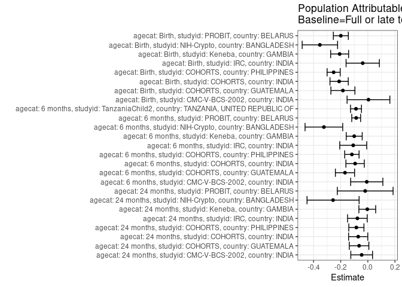

## Results Table

### Parameter: TSM

| agecat | studyid | country | intervention_level | baseline_level | estimate | ci_lower | ci_upper |
| --- | --- | --- | --- | --- | --- | --- | --- |
| Birth | CMC-V-BCS-2002 | INDIA | Full or late term | NA | -0.9659483 | -1.2562663 | -0.6756303 |
| Birth | CMC-V-BCS-2002 | INDIA | Preterm | NA | -0.9286364 | -1.5552049 | -0.3020679 |
| Birth | CMC-V-BCS-2002 | INDIA | Early term | NA | -0.9647826 | -1.3170438 | -0.6125215 |
| Birth | COHORTS | GUATEMALA | Full or late term | NA | 0.2367449 | 0.1129997 | 0.3604901 |
| Birth | COHORTS | GUATEMALA | Preterm | NA | -0.3893684 | -0.6838031 | -0.0949338 |
| Birth | COHORTS | GUATEMALA | Early term | NA | -0.0607182 | -0.2277653 | 0.1063288 |
| Birth | COHORTS | INDIA | Full or late term | NA | -0.3955789 | -0.4832187 | -0.3079392 |
| Birth | COHORTS | INDIA | Preterm | NA | -0.9073333 | -1.0436769 | -0.7709898 |
| Birth | COHORTS | INDIA | Early term | NA | -0.6873516 | -0.7862577 | -0.5884455 |
| Birth | COHORTS | PHILIPPINES | Full or late term | NA | 0.0027663 | -0.0556001 | 0.0611327 |
| Birth | COHORTS | PHILIPPINES | Preterm | NA | -0.6426810 | -0.7403472 | -0.5450149 |
| Birth | COHORTS | PHILIPPINES | Early term | NA | -0.2806276 | -0.3376182 | -0.2236370 |
| Birth | IRC | INDIA | Full or late term | NA | -0.2726891 | -0.4770060 | -0.0683722 |
| Birth | IRC | INDIA | Preterm | NA | -0.9105556 | -1.4543481 | -0.3667630 |
| Birth | IRC | INDIA | Early term | NA | -0.1770526 | -0.4916498 | 0.1375445 |
| Birth | Keneba | GAMBIA | Full or late term | NA | 0.2357084 | 0.1498363 | 0.3215806 |
| Birth | Keneba | GAMBIA | Preterm | NA | -0.6743404 | -0.8604855 | -0.4881954 |
| Birth | Keneba | GAMBIA | Early term | NA | 0.0506960 | -0.0506873 | 0.1520793 |
| Birth | NIH-Crypto | BANGLADESH | Full or late term | NA | -0.5560494 | -0.7024649 | -0.4096338 |
| Birth | NIH-Crypto | BANGLADESH | Preterm | NA | -1.3715175 | -1.4828336 | -1.2602014 |
| Birth | NIH-Crypto | BANGLADESH | Early term | NA | -0.7130671 | -0.8150279 | -0.6111063 |
| Birth | PROBIT | BELARUS | Full or late term | NA | 1.5103739 | 1.3567535 | 1.6639944 |
| Birth | PROBIT | BELARUS | Preterm | NA | 0.3876271 | 0.1152650 | 0.6599892 |
| Birth | PROBIT | BELARUS | Early term | NA | 1.1569760 | 0.9741003 | 1.3398516 |
| 6 months | CMC-V-BCS-2002 | INDIA | Full or late term | NA | -1.3778145 | -1.5599142 | -1.1957148 |
| 6 months | CMC-V-BCS-2002 | INDIA | Preterm | NA | -1.5883013 | -2.0368105 | -1.1397921 |
| 6 months | CMC-V-BCS-2002 | INDIA | Early term | NA | -1.2784940 | -1.5569704 | -1.0000176 |
| 6 months | COHORTS | GUATEMALA | Full or late term | NA | -1.6630848 | -1.7605992 | -1.5655705 |
| 6 months | COHORTS | GUATEMALA | Preterm | NA | -2.1353982 | -2.3427878 | -1.9280087 |
| 6 months | COHORTS | GUATEMALA | Early term | NA | -1.9793839 | -2.1210237 | -1.8377441 |
| 6 months | COHORTS | INDIA | Full or late term | NA | -0.8693310 | -0.9602133 | -0.7784487 |
| 6 months | COHORTS | INDIA | Preterm | NA | -1.1462876 | -1.2693237 | -1.0232516 |
| 6 months | COHORTS | INDIA | Early term | NA | -0.9595056 | -1.0580956 | -0.8609156 |
| 6 months | COHORTS | PHILIPPINES | Full or late term | NA | -1.0235409 | -1.0899673 | -0.9571144 |
| 6 months | COHORTS | PHILIPPINES | Preterm | NA | -1.3508901 | -1.4485191 | -1.2532610 |
| 6 months | COHORTS | PHILIPPINES | Early term | NA | -1.1414088 | -1.2053739 | -1.0774438 |
| 6 months | IRC | INDIA | Full or late term | NA | -1.1243307 | -1.2930271 | -0.9556342 |
| 6 months | IRC | INDIA | Preterm | NA | -1.7184524 | -2.1781138 | -1.2587910 |
| 6 months | IRC | INDIA | Early term | NA | -1.2982646 | -1.5317130 | -1.0648162 |
| 6 months | Keneba | GAMBIA | Full or late term | NA | -0.7944516 | -0.8787022 | -0.7102010 |
| 6 months | Keneba | GAMBIA | Preterm | NA | -1.2775813 | -1.4220615 | -1.1331012 |
| 6 months | Keneba | GAMBIA | Early term | NA | -0.8688767 | -0.9537132 | -0.7840402 |
| 6 months | NIH-Crypto | BANGLADESH | Full or late term | NA | -0.8747097 | -1.0329276 | -0.7164917 |
| 6 months | NIH-Crypto | BANGLADESH | Preterm | NA | -1.4437251 | -1.5646460 | -1.3228042 |
| 6 months | NIH-Crypto | BANGLADESH | Early term | NA | -1.1621359 | -1.2625414 | -1.0617304 |
| 6 months | PROBIT | BELARUS | Full or late term | NA | 0.1838198 | 0.0854585 | 0.2821811 |
| 6 months | PROBIT | BELARUS | Preterm | NA | -0.3473593 | -0.5566073 | -0.1381114 |
| 6 months | PROBIT | BELARUS | Early term | NA | 0.0366768 | -0.0615206 | 0.1348743 |
| 6 months | TanzaniaChild2 | TANZANIA, UNITED REPUBLIC OF | Full or late term | NA | -0.4548051 | -0.5192960 | -0.3903141 |
| 6 months | TanzaniaChild2 | TANZANIA, UNITED REPUBLIC OF | Preterm | NA | -0.7272680 | -0.8606101 | -0.5939260 |
| 6 months | TanzaniaChild2 | TANZANIA, UNITED REPUBLIC OF | Early term | NA | -0.6493296 | -0.7505123 | -0.5481469 |
| 24 months | CMC-V-BCS-2002 | INDIA | Full or late term | NA | -2.4866041 | -2.6194176 | -2.3537905 |
| 24 months | CMC-V-BCS-2002 | INDIA | Preterm | NA | -2.6304808 | -2.9111477 | -2.3498138 |
| 24 months | CMC-V-BCS-2002 | INDIA | Early term | NA | -2.5858929 | -2.7697478 | -2.4020379 |
| 24 months | COHORTS | GUATEMALA | Full or late term | NA | -2.9267200 | -3.0347363 | -2.8187037 |
| 24 months | COHORTS | GUATEMALA | Preterm | NA | -3.0413084 | -3.2635929 | -2.8190240 |
| 24 months | COHORTS | GUATEMALA | Early term | NA | -3.0960335 | -3.2475461 | -2.9445210 |
| 24 months | COHORTS | INDIA | Full or late term | NA | -2.0580354 | -2.1536933 | -1.9623775 |
| 24 months | COHORTS | INDIA | Preterm | NA | -2.2509836 | -2.3792015 | -2.1227657 |
| 24 months | COHORTS | INDIA | Early term | NA | -2.1354338 | -2.2359187 | -2.0349488 |
| 24 months | COHORTS | PHILIPPINES | Full or late term | NA | -2.3300746 | -2.3994947 | -2.2606546 |
| 24 months | COHORTS | PHILIPPINES | Preterm | NA | -2.5064133 | -2.6085462 | -2.4042803 |
| 24 months | COHORTS | PHILIPPINES | Early term | NA | -2.4473998 | -2.5197663 | -2.3750333 |
| 24 months | IRC | INDIA | Full or late term | NA | -1.7195667 | -1.8347491 | -1.6043843 |
| 24 months | IRC | INDIA | Preterm | NA | -2.2000000 | -2.4823353 | -1.9176647 |
| 24 months | IRC | INDIA | Early term | NA | -1.8197959 | -2.0140458 | -1.6255460 |
| 24 months | Keneba | GAMBIA | Full or late term | NA | -1.5761023 | -1.6610542 | -1.4911505 |
| 24 months | Keneba | GAMBIA | Preterm | NA | -1.8541647 | -2.0137133 | -1.6946160 |
| 24 months | Keneba | GAMBIA | Early term | NA | -1.4792720 | -1.5764930 | -1.3820509 |
| 24 months | NIH-Crypto | BANGLADESH | Full or late term | NA | -1.1850633 | -1.3927855 | -0.9773411 |
| 24 months | NIH-Crypto | BANGLADESH | Preterm | NA | -1.6218750 | -1.7555791 | -1.4881709 |
| 24 months | NIH-Crypto | BANGLADESH | Early term | NA | -1.3649339 | -1.4859660 | -1.2439019 |
| 24 months | PROBIT | BELARUS | Full or late term | NA | -0.1249728 | -0.5808461 | 0.3309004 |
| 24 months | PROBIT | BELARUS | Preterm | NA | -0.3671533 | -0.7126869 | -0.0216197 |
| 24 months | PROBIT | BELARUS | Early term | NA | -0.1488717 | -0.3427424 | 0.0449991 |

### Parameter: E(Y)

| agecat | studyid | country | intervention_level | baseline_level | estimate | ci_lower | ci_upper |
| --- | --- | --- | --- | --- | --- | --- | --- |
| Birth | CMC-V-BCS-2002 | INDIA | NA | NA | -0.9611957 | -1.1776967 | -0.7446946 |
| Birth | COHORTS | GUATEMALA | NA | NA | 0.0530794 | -0.0441925 | 0.1503513 |
| Birth | COHORTS | INDIA | NA | NA | -0.6072158 | -0.6675691 | -0.5468624 |
| Birth | COHORTS | PHILIPPINES | NA | NA | -0.2492460 | -0.2884729 | -0.2100192 |
| Birth | IRC | INDIA | NA | NA | -0.3102981 | -0.4751168 | -0.1454794 |
| Birth | Keneba | GAMBIA | NA | NA | 0.0278680 | -0.0365315 | 0.0922674 |
| Birth | NIH-Crypto | BANGLADESH | NA | NA | -0.9094945 | -0.9809370 | -0.8380521 |
| Birth | PROBIT | BELARUS | NA | NA | 1.3114417 | 1.1524752 | 1.4704082 |
| 6 months | CMC-V-BCS-2002 | INDIA | NA | NA | -1.3856004 | -1.5319935 | -1.2392073 |
| 6 months | COHORTS | GUATEMALA | NA | NA | -1.8315428 | -1.9081267 | -1.7549589 |
| 6 months | COHORTS | INDIA | NA | NA | -0.9630335 | -1.0220763 | -0.9039908 |
| 6 months | COHORTS | PHILIPPINES | NA | NA | -1.1409862 | -1.1830414 | -1.0989310 |
| 6 months | IRC | INDIA | NA | NA | -1.2321263 | -1.3660720 | -1.0981806 |
| 6 months | Keneba | GAMBIA | NA | NA | -0.8948084 | -0.9510697 | -0.8385471 |
| 6 months | NIH-Crypto | BANGLADESH | NA | NA | -1.1986783 | -1.2700937 | -1.1272630 |
| 6 months | PROBIT | BELARUS | NA | NA | 0.0980074 | 0.0062724 | 0.1897424 |
| 6 months | TanzaniaChild2 | TANZANIA, UNITED REPUBLIC OF | NA | NA | -0.5419570 | -0.5926042 | -0.4913098 |
| 24 months | CMC-V-BCS-2002 | INDIA | NA | NA | -2.5319389 | -2.6335015 | -2.4303762 |
| 24 months | COHORTS | GUATEMALA | NA | NA | -2.9911195 | -3.0733804 | -2.9088586 |
| 24 months | COHORTS | INDIA | NA | NA | -2.1289450 | -2.1901830 | -2.0677069 |
| 24 months | COHORTS | PHILIPPINES | NA | NA | -2.4144884 | -2.4596605 | -2.3693164 |
| 24 months | IRC | INDIA | NA | NA | -1.7964915 | -1.8912047 | -1.7017782 |
| 24 months | Keneba | GAMBIA | NA | NA | -1.5800865 | -1.6398819 | -1.5202911 |
| 24 months | NIH-Crypto | BANGLADESH | NA | NA | -1.4412646 | -1.5249156 | -1.3576135 |
| 24 months | PROBIT | BELARUS | NA | NA | -0.1442891 | -0.4253755 | 0.1367972 |

### Parameter: ATE

| agecat | studyid | country | intervention_level | baseline_level | estimate | ci_lower | ci_upper |
| --- | --- | --- | --- | --- | --- | --- | --- |
| Birth | CMC-V-BCS-2002 | INDIA | Full or late term | Full or late term | 0.0000000 | 0.0000000 | 0.0000000 |
| Birth | CMC-V-BCS-2002 | INDIA | Preterm | Full or late term | 0.0373119 | -0.6532478 | 0.7278716 |
| Birth | CMC-V-BCS-2002 | INDIA | Early term | Full or late term | 0.0011657 | -0.4553127 | 0.4576440 |
| Birth | COHORTS | GUATEMALA | Full or late term | Full or late term | 0.0000000 | 0.0000000 | 0.0000000 |
| Birth | COHORTS | GUATEMALA | Preterm | Full or late term | -0.6261133 | -0.9454950 | -0.3067316 |
| Birth | COHORTS | GUATEMALA | Early term | Full or late term | -0.2974631 | -0.5053515 | -0.0895747 |
| Birth | COHORTS | INDIA | Full or late term | Full or late term | 0.0000000 | 0.0000000 | 0.0000000 |
| Birth | COHORTS | INDIA | Preterm | Full or late term | -0.5117544 | -0.6738355 | -0.3496733 |
| Birth | COHORTS | INDIA | Early term | Full or late term | -0.2917727 | -0.4239208 | -0.1596245 |
| Birth | COHORTS | PHILIPPINES | Full or late term | Full or late term | 0.0000000 | 0.0000000 | 0.0000000 |
| Birth | COHORTS | PHILIPPINES | Preterm | Full or late term | -0.6454474 | -0.7592248 | -0.5316699 |
| Birth | COHORTS | PHILIPPINES | Early term | Full or late term | -0.2833939 | -0.3649694 | -0.2018184 |
| Birth | IRC | INDIA | Full or late term | Full or late term | 0.0000000 | 0.0000000 | 0.0000000 |
| Birth | IRC | INDIA | Preterm | Full or late term | -0.6378665 | -1.2187759 | -0.0569570 |
| Birth | IRC | INDIA | Early term | Full or late term | 0.0956364 | -0.2794859 | 0.4707588 |
| Birth | Keneba | GAMBIA | Full or late term | Full or late term | 0.0000000 | 0.0000000 | 0.0000000 |
| Birth | Keneba | GAMBIA | Preterm | Full or late term | -0.9100489 | -1.1150464 | -0.7050513 |
| Birth | Keneba | GAMBIA | Early term | Full or late term | -0.1850125 | -0.3178756 | -0.0521494 |
| Birth | NIH-Crypto | BANGLADESH | Full or late term | Full or late term | 0.0000000 | 0.0000000 | 0.0000000 |
| Birth | NIH-Crypto | BANGLADESH | Preterm | Full or late term | -0.8154681 | -0.9993942 | -0.6315421 |
| Birth | NIH-Crypto | BANGLADESH | Early term | Full or late term | -0.1570177 | -0.3354372 | 0.0214018 |
| Birth | PROBIT | BELARUS | Full or late term | Full or late term | 0.0000000 | 0.0000000 | 0.0000000 |
| Birth | PROBIT | BELARUS | Preterm | Full or late term | -1.1227468 | -1.3558762 | -0.8896174 |
| Birth | PROBIT | BELARUS | Early term | Full or late term | -0.3533980 | -0.4736517 | -0.2331443 |
| 6 months | CMC-V-BCS-2002 | INDIA | Full or late term | Full or late term | 0.0000000 | 0.0000000 | 0.0000000 |
| 6 months | CMC-V-BCS-2002 | INDIA | Preterm | Full or late term | -0.2104868 | -0.6945538 | 0.2735801 |
| 6 months | CMC-V-BCS-2002 | INDIA | Early term | Full or late term | 0.0993205 | -0.2334097 | 0.4320507 |
| 6 months | COHORTS | GUATEMALA | Full or late term | Full or late term | 0.0000000 | 0.0000000 | 0.0000000 |
| 6 months | COHORTS | GUATEMALA | Preterm | Full or late term | -0.4723134 | -0.7014846 | -0.2431421 |
| 6 months | COHORTS | GUATEMALA | Early term | Full or late term | -0.3162991 | -0.4882609 | -0.1443372 |
| 6 months | COHORTS | INDIA | Full or late term | Full or late term | 0.0000000 | 0.0000000 | 0.0000000 |
| 6 months | COHORTS | INDIA | Preterm | Full or late term | -0.2769566 | -0.4299189 | -0.1239943 |
| 6 months | COHORTS | INDIA | Early term | Full or late term | -0.0901746 | -0.2242626 | 0.0439133 |
| 6 months | COHORTS | PHILIPPINES | Full or late term | Full or late term | 0.0000000 | 0.0000000 | 0.0000000 |
| 6 months | COHORTS | PHILIPPINES | Preterm | Full or late term | -0.3273492 | -0.4454335 | -0.2092649 |
| 6 months | COHORTS | PHILIPPINES | Early term | Full or late term | -0.1178680 | -0.2100852 | -0.0256508 |
| 6 months | IRC | INDIA | Full or late term | Full or late term | 0.0000000 | 0.0000000 | 0.0000000 |
| 6 months | IRC | INDIA | Preterm | Full or late term | -0.5941217 | -1.0837615 | -0.1044820 |
| 6 months | IRC | INDIA | Early term | Full or late term | -0.1739339 | -0.4619559 | 0.1140880 |
| 6 months | Keneba | GAMBIA | Full or late term | Full or late term | 0.0000000 | 0.0000000 | 0.0000000 |
| 6 months | Keneba | GAMBIA | Preterm | Full or late term | -0.4831297 | -0.6503800 | -0.3158794 |
| 6 months | Keneba | GAMBIA | Early term | Full or late term | -0.0744251 | -0.1939884 | 0.0451383 |
| 6 months | NIH-Crypto | BANGLADESH | Full or late term | Full or late term | 0.0000000 | 0.0000000 | 0.0000000 |
| 6 months | NIH-Crypto | BANGLADESH | Preterm | Full or late term | -0.5690154 | -0.7681505 | -0.3698803 |
| 6 months | NIH-Crypto | BANGLADESH | Early term | Full or late term | -0.2874262 | -0.4748140 | -0.1000385 |
| 6 months | PROBIT | BELARUS | Full or late term | Full or late term | 0.0000000 | 0.0000000 | 0.0000000 |
| 6 months | PROBIT | BELARUS | Preterm | Full or late term | -0.5311791 | -0.7240199 | -0.3383383 |
| 6 months | PROBIT | BELARUS | Early term | Full or late term | -0.1471429 | -0.2135984 | -0.0806875 |
| 6 months | TanzaniaChild2 | TANZANIA, UNITED REPUBLIC OF | Full or late term | Full or late term | 0.0000000 | 0.0000000 | 0.0000000 |
| 6 months | TanzaniaChild2 | TANZANIA, UNITED REPUBLIC OF | Preterm | Full or late term | -0.2724630 | -0.4205818 | -0.1243442 |
| 6 months | TanzaniaChild2 | TANZANIA, UNITED REPUBLIC OF | Early term | Full or late term | -0.1945245 | -0.3145121 | -0.0745370 |
| 24 months | CMC-V-BCS-2002 | INDIA | Full or late term | Full or late term | 0.0000000 | 0.0000000 | 0.0000000 |
| 24 months | CMC-V-BCS-2002 | INDIA | Preterm | Full or late term | -0.1438767 | -0.4543817 | 0.1666283 |
| 24 months | CMC-V-BCS-2002 | INDIA | Early term | Full or late term | -0.0992888 | -0.3260973 | 0.1275197 |
| 24 months | COHORTS | GUATEMALA | Full or late term | Full or late term | 0.0000000 | 0.0000000 | 0.0000000 |
| 24 months | COHORTS | GUATEMALA | Preterm | Full or late term | -0.1145884 | -0.3617278 | 0.1325510 |
| 24 months | COHORTS | GUATEMALA | Early term | Full or late term | -0.1693135 | -0.3553876 | 0.0167606 |
| 24 months | COHORTS | INDIA | Full or late term | Full or late term | 0.0000000 | 0.0000000 | 0.0000000 |
| 24 months | COHORTS | INDIA | Preterm | Full or late term | -0.1929482 | -0.3529178 | -0.0329787 |
| 24 months | COHORTS | INDIA | Early term | Full or late term | -0.0773984 | -0.2161343 | 0.0613375 |
| 24 months | COHORTS | PHILIPPINES | Full or late term | Full or late term | 0.0000000 | 0.0000000 | 0.0000000 |
| 24 months | COHORTS | PHILIPPINES | Preterm | Full or late term | -0.1763386 | -0.2998307 | -0.0528466 |
| 24 months | COHORTS | PHILIPPINES | Early term | Full or late term | -0.1173252 | -0.2176051 | -0.0170453 |
| 24 months | IRC | INDIA | Full or late term | Full or late term | 0.0000000 | 0.0000000 | 0.0000000 |
| 24 months | IRC | INDIA | Preterm | Full or late term | -0.4804333 | -0.7853599 | -0.1755067 |
| 24 months | IRC | INDIA | Early term | Full or late term | -0.1002293 | -0.3260611 | 0.1256026 |
| 24 months | Keneba | GAMBIA | Full or late term | Full or late term | 0.0000000 | 0.0000000 | 0.0000000 |
| 24 months | Keneba | GAMBIA | Preterm | Full or late term | -0.2780623 | -0.4588179 | -0.0973067 |
| 24 months | Keneba | GAMBIA | Early term | Full or late term | 0.0968303 | -0.0322771 | 0.2259378 |
| 24 months | NIH-Crypto | BANGLADESH | Full or late term | Full or late term | 0.0000000 | 0.0000000 | 0.0000000 |
| 24 months | NIH-Crypto | BANGLADESH | Preterm | Full or late term | -0.4368117 | -0.6838447 | -0.1897787 |
| 24 months | NIH-Crypto | BANGLADESH | Early term | Full or late term | -0.1798706 | -0.4202813 | 0.0605400 |
| 24 months | PROBIT | BELARUS | Full or late term | Full or late term | 0.0000000 | 0.0000000 | 0.0000000 |
| 24 months | PROBIT | BELARUS | Preterm | Full or late term | -0.2421804 | -0.8027554 | 0.3183945 |
| 24 months | PROBIT | BELARUS | Early term | Full or late term | -0.0238988 | -0.4377461 | 0.3899485 |

### Parameter: PAR

| agecat | studyid | country | intervention_level | baseline_level | estimate | ci_lower | ci_upper |
| --- | --- | --- | --- | --- | --- | --- | --- |
| Birth | CMC-V-BCS-2002 | INDIA | Full or late term | NA | 0.0047526 | -0.1529985 | 0.1625037 |
| Birth | COHORTS | GUATEMALA | Full or late term | NA | -0.1836655 | -0.2722580 | -0.0950729 |
| Birth | COHORTS | INDIA | Full or late term | NA | -0.2116368 | -0.2791008 | -0.1441729 |
| Birth | COHORTS | PHILIPPINES | Full or late term | NA | -0.2520124 | -0.3002079 | -0.2038168 |
| Birth | IRC | INDIA | Full or late term | NA | -0.0376090 | -0.1603289 | 0.0851108 |
| Birth | Keneba | GAMBIA | Full or late term | NA | -0.2078405 | -0.2739922 | -0.1416887 |
| Birth | NIH-Crypto | BANGLADESH | Full or late term | NA | -0.3534452 | -0.4840315 | -0.2228588 |
| Birth | PROBIT | BELARUS | Full or late term | NA | -0.1989322 | -0.2541792 | -0.1436853 |
| 6 months | CMC-V-BCS-2002 | INDIA | Full or late term | NA | -0.0077859 | -0.1264140 | 0.1108421 |
| 6 months | COHORTS | GUATEMALA | Full or late term | NA | -0.1684579 | -0.2391560 | -0.0977599 |
| 6 months | COHORTS | INDIA | Full or late term | NA | -0.0937026 | -0.1614819 | -0.0259232 |
| 6 months | COHORTS | PHILIPPINES | Full or late term | NA | -0.1174454 | -0.1704061 | -0.0644846 |
| 6 months | IRC | INDIA | Full or late term | NA | -0.1077956 | -0.2071602 | -0.0084311 |
| 6 months | Keneba | GAMBIA | Full or late term | NA | -0.1003568 | -0.1592207 | -0.0414929 |
| 6 months | NIH-Crypto | BANGLADESH | Full or late term | NA | -0.3239686 | -0.4628198 | -0.1851175 |
| 6 months | PROBIT | BELARUS | Full or late term | NA | -0.0858124 | -0.1185655 | -0.0530592 |
| 6 months | TanzaniaChild2 | TANZANIA, UNITED REPUBLIC OF | Full or late term | NA | -0.0871519 | -0.1274405 | -0.0468634 |
| 24 months | CMC-V-BCS-2002 | INDIA | Full or late term | NA | -0.0453348 | -0.1254795 | 0.0348099 |
| 24 months | COHORTS | GUATEMALA | Full or late term | NA | -0.0643995 | -0.1364820 | 0.0076830 |
| 24 months | COHORTS | INDIA | Full or late term | NA | -0.0709096 | -0.1415873 | -0.0002318 |
| 24 months | COHORTS | PHILIPPINES | Full or late term | NA | -0.0844138 | -0.1403601 | -0.0284675 |
| 24 months | IRC | INDIA | Full or late term | NA | -0.0769248 | -0.1492340 | -0.0046155 |
| 24 months | Keneba | GAMBIA | Full or late term | NA | -0.0039842 | -0.0659332 | 0.0579649 |
| 24 months | NIH-Crypto | BANGLADESH | Full or late term | NA | -0.2562013 | -0.4482494 | -0.0641532 |
| 24 months | PROBIT | BELARUS | Full or late term | NA | -0.0193163 | -0.2249317 | 0.1862992 |